**POLS/CSSS 503, University of Washington, Spring 2015**

# POLS 503: Problem Set 4 Solutions

Jeffrey B. Arnold

May 15, 2015

# Setup

```r
library("ggplot2")
library("dplyr")
library("broom")
library("tidyr")
source("http://uw-pols503.github.io/pols_503_sp15/hw/hw4-functions.R")
```

# Problems

## Showing Confidence

We will revisit the sprinters data we considered in Problem Set 2.

```r
sprinters <- read.csv("http://uw-pols503.github.io/pols_503_sp15/data/sprinters.csv")
```

**a.** Estimate a linear regression of `finish` on `year` and `women`:

```r
mod1 <- lm(finish ~ year + women, data = sprinters)
```

We can create a plot in several ways. Using the observed values and `augment()`: This gets the critical value of the Student’s $t$ distribution for the degrees of freedom in the regression and a 95% confidence interval (using 2 should be good enough, but I’m feeling pedantic today).

```r
tstar <- - qt((1 - 0.95)/ 2, df = mod1$df.residual)
```

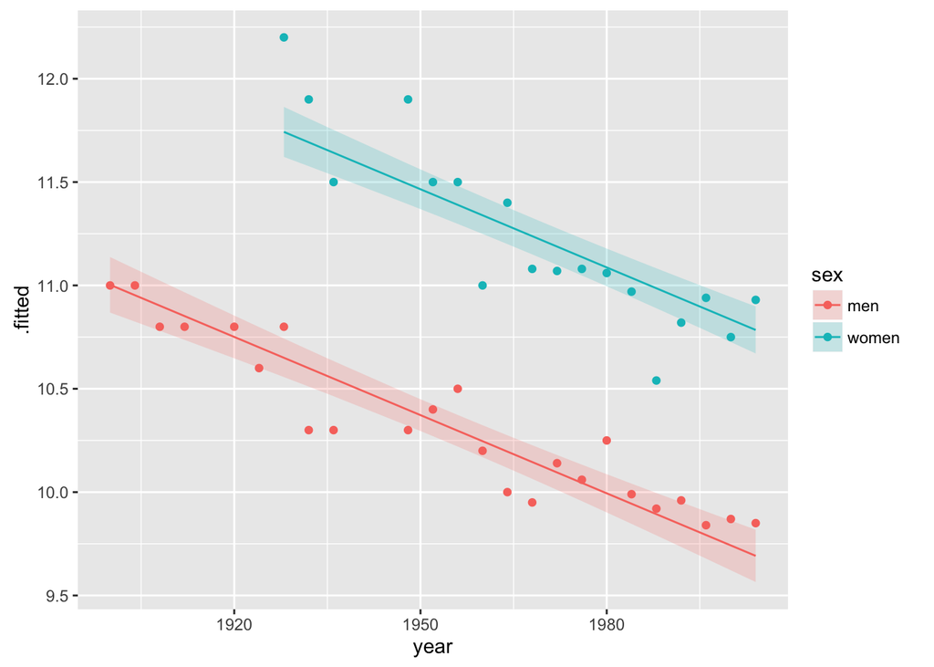

```r
ggplot(mutate(augment(mod1),
              sex = ifelse(as.logical(women), "women", "men")),
              aes(x = year, y = .fitted,
                  ymax = .fitted + .se.fit * tstar,
                  ymin = .fitted - .se.fit * tstar,
                  colour = sex, fill = sex)) +
  geom_ribbon(alpha = 0.2, colour = NA) +
  geom_line() +
  geom_point(mapping = aes(y = finish))
```

Using `predict()`:

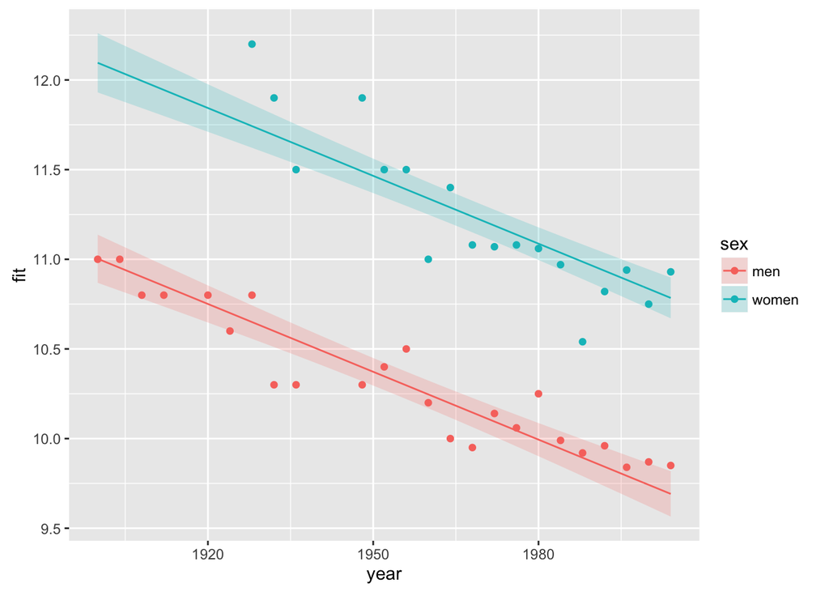

```r
mod1_newdata <-
  expand.grid(year = seq(min(sprinters$year), max(sprinters$year)),
                        women = c(0, 1))
mod1_yhat <-
  bind_cols(mod1_newdata,
            as.data.frame(predict(mod1, mod1_newdata, interval = "confidence"))) %>%
  mutate(sex = ifelse(as.logical(women), "women", "men"))

ggplot() +
  geom_ribbon(data = mod1_yhat,
              mapping = aes(x = year, ymin = lwr, ymax = upr, fill = sex), alpha = 0.2) +
  geom_line(data = mod1_yhat,
            mapping = aes(x = year, y = fit, colour = sex)) +
  geom_point(data = sprinters %>%
  mutate(sex = ifelse(as.logical(women), "women", "men")),
  mapping = aes(y = finish, x = year, colour = sex))
```

**b.** In this problem, I’ll estimate a linear regression of `finish` on `year` and `women` and the interaction thereof:

```r
mod2 <- lm(finish ~ year * women, data = sprinters)
```

Although the plot of predicted values can be created in several ways (see the previous), but this time I’ll use augment.

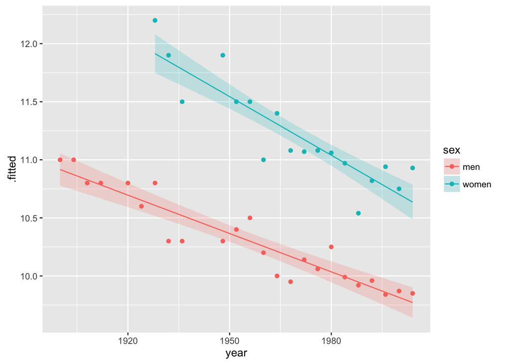

```r
ggplot(mutate(augment(mod2),
              sex = ifelse(as.logical(women), "women", "men")),
              aes(x = year, y = .fitted,
                  ymax = .fitted + .se.fit * tstar,
                  ymin = .fitted - .se.fit * tstar,
                  colour = sex, fill = sex)) +
  geom_ribbon(alpha = 0.2, colour = NA) +
  geom_line() +
  geom_point(mapping = aes(y = finish))
```

**c.** In this problem, I’ll estimate a linear regression of `finish` on `year`, `year` squared, and `women` and the interaction thereof:

```r
mod3 <- lm(finish ~ year * women + I(year ^ 2) * women, data = sprinters)
```

Although the plot of predicted values can be created in several ways (see the previous), but this time I’ll use `augment()`.

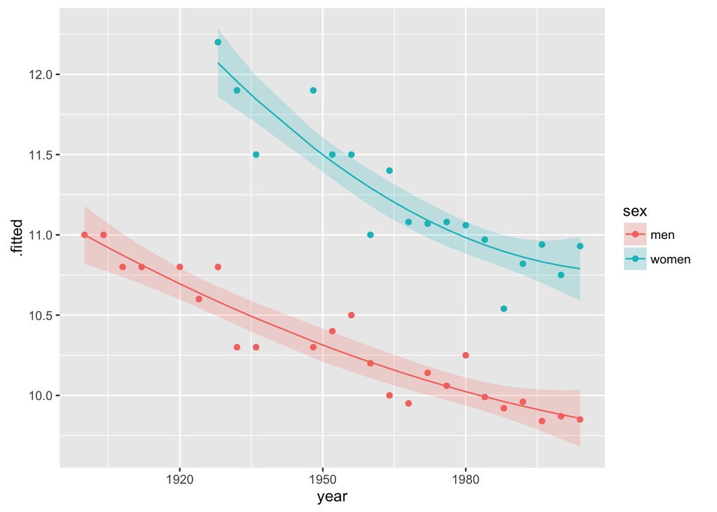

```r
ggplot(mutate(augment(mod3),
              sex = ifelse(as.logical(women), "women", "men")),
              aes(x = year, y = .fitted,
                  ymax = .fitted + .se.fit * tstar,
                  ymin = .fitted - .se.fit * tstar,
                  colour = sex, fill = sex)) +
  geom_ribbon(alpha = 0.2, colour = NA) +
  geom_line() +
  geom_point(mapping = aes(y = finish))
```

**d.** Compare the visual fit of these models to the data within the observed period. Which do you find plausible fits?

**e.** They have different predictions in 2156.

```r
predict(mod1, newdata = expand.grid(women = c(0, 1), year = 2156), interval = "confidence")
```

```
##        fit      lwr      upr
## 1 7.775109 7.358004 8.192213
## 2 8.867921 8.476930 9.258911
```

```r
predict(mod2, newdata = expand.grid(women = c(0, 1), year = 2156), interval = "confidence")
```

```
##        fit      lwr      upr
## 1 8.098462 7.648238 8.548686
## 2 8.078666 7.404166 8.753165
```

```r
predict(mod3, newdata = expand.grid(women = c(0, 1), year = 2156), interval = "confidence")
```

```
##        fit      lwr      upr
## 1 10.15756 7.050226 13.26490
## 2 14.10124 8.584043 19.61843
```

**f.** Now create a new variable, the ratio of men’s time to women’s time in each year. Logit-transform this variable and regress it on year. Plot the results,with confidence intervals, on the scale of the ratio men’s time to women’s time (i.e., transform it back from logit). Does this approach make any assumptions about men’s times or women’s times that might be problematic?

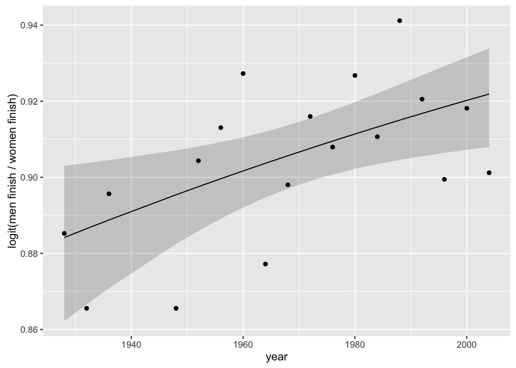

```r
sprinters2 <-
  sprinters %>%
  mutate(sex = ifelse(as.logical(women), "women", "men")) %>%
  select(-women) %>%
  spread(sex, finish) %>%
  mutate(rat = men / women,
         logit_rat = log(rat / (1 - rat))) %>%
  na.omit()

logit <- function(x) log(x / (1 - x))
inv_logit <- function(x) exp(x) / (exp(x) + 1)

mod4 <- lm(logit(rat) ~ year, data = sprinters2)

ggplot(augment(mod4),
       aes(x = year,
           y = inv_logit(.fitted),
           ymax = inv_logit(.fitted + .se.fit * 2),
           ymin = inv_logit(.fitted - .se.fit * 2))) +
  geom_ribbon(alpha = 0.2, colour = NA) +
  geom_line() +
  geom_point(mapping = aes(y = inv_logit(logit.rat.))) +
  scale_y_continuous("logit(men finish / women finish)")
```

## Model Selection: Oil & Democracy

```r
ross95 <- read.csv("http://uw-pols503.github.io/pols_503_sp15/data/rossoildata.csv") %>%
   group_by(id) %>%
   mutate(oilL5 = lag(oil, 5),
          metalL5 = lag(metal, 5),
          GDPcapL5 = lag(GDPcap, 5)) %>%
   filter(year == 1995) %>%
   select(regime1, oilL5, metalL5, GDPcapL5, islam, oecd, cty_name, id, id1) %>%
   na.omit() %>%
   ungroup()
```

**a.**

```r
oil_mod1 <- lm(regime1 ~ oilL5 + metalL5 + GDPcapL5 + islam + oecd, data = ross95)
```

The standard error of the regression is

```r
glance(oil_mod1)$sigma
```

```
## [1] 2.296229
```

The change in `regime1` associated with a change from the 50th percentile to the 95th percentile of oil, holding all other variables at their means (including binary) is:

```r
oil_mod1_oil_predict_lo <-
  predict(oil_mod1,
          newdata = summarise(ross95,
                              oilL5 = median(oilL5),
                              metalL5 = mean(metalL5),
                              islam = mean(islam),
                              oecd = mean(oecd),
                              GDPcapL5 = mean(GDPcapL5)))

oil_mod1_oil_predict_hi <-
  predict(oil_mod1,
          newdata = summarise(ross95,
                              oilL5 = quantile(oilL5, 0.95),
                              metalL5 = mean(metalL5),
                              islam = mean(islam),
                              oecd = mean(oecd),
                              GDPcapL5 = mean(GDPcapL5)))

oil_mod1_oil_predict_hi -
  oil_mod1_oil_predict_lo
```

```
##         1
## -3.434682
```

**b.** Using the residuals from the regression in part a., create the following diagnostic plots:

```r
oil_mod1_aug <- augment(oil_mod1)
```

Plot predicted `regime1` versus `regime1`:

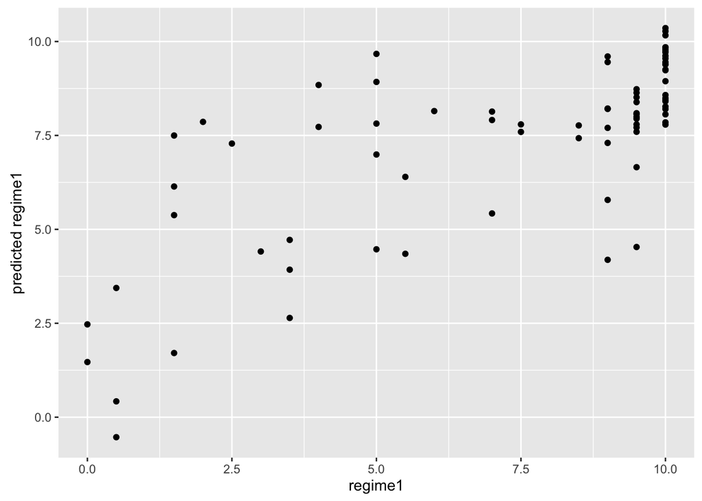

```r
ggplot(oil_mod1_aug, aes(x = regime1, y = .fitted)) +
  geom_point() +
  scale_y_continuous("predicted regime1")
```

[figure not shown]

```r
ggplot(oil_mod1_aug, aes(x = regime1, y = .fitted)) +
  geom_point() +
  scale_y_continuous("predicted regime1")
```

```r
oil_mod1_resid_vs_x <-
  oil_mod1_aug %>%
    select(regime1, oilL5, metalL5, GDPcapL5, islam, oecd, .resid) %>%
    gather(variable, x, -.resid)
```

Then it is easy to plot them on one plot,

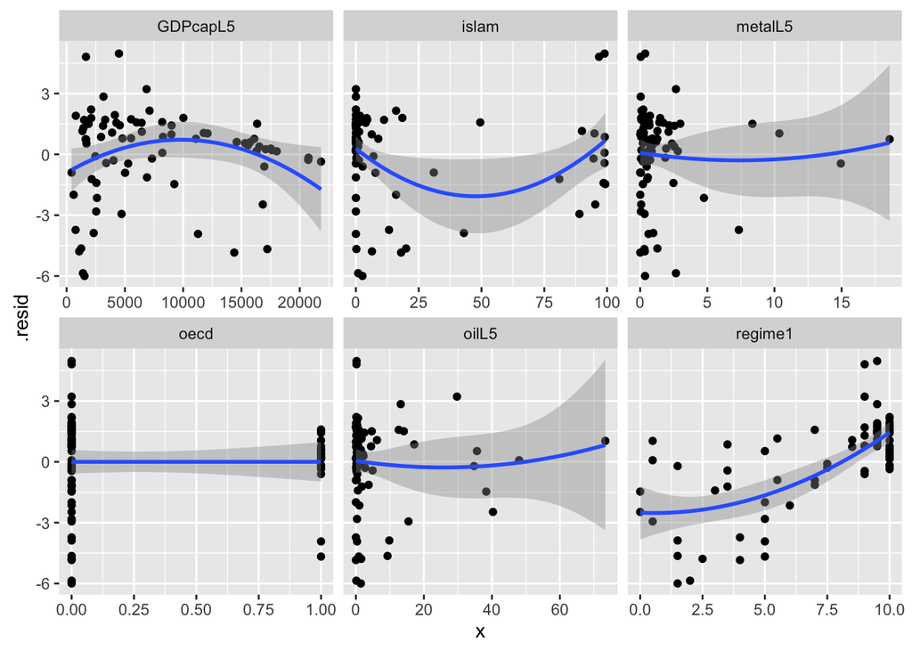

```r
ggplot(oil_mod1_resid_vs_x, aes(x = x, y = .resid)) +
  geom_point() +
  geom_smooth(method = "lm", formula = y ~ x + I(x^2)) +
  facet_wrap(~ variable, scales = "free_x")
```

Alternatively, plot $x$ versus the $\sqrt{\epsilon_i^2}$

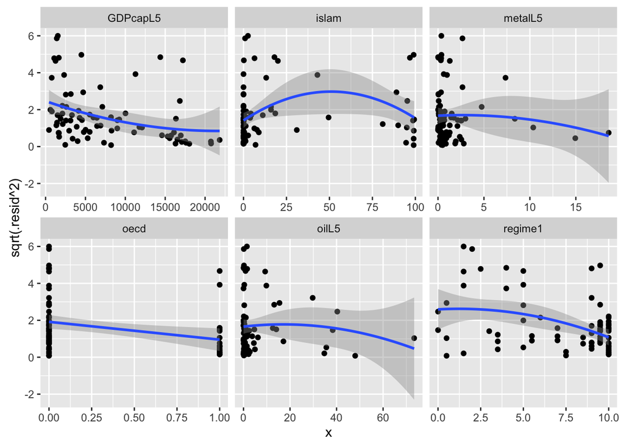

```r
ggplot(oil_mod1_resid_vs_x, aes(x = x, y = sqrt(.resid^2))) +
  geom_point() +
  geom_smooth(method = "lm", formula = y ~ x + I(x^2)) +
  facet_wrap(~ variable, scales = "free_x")
```

```r
bind_cols(tidy(oil_mod1),
          data.frame(std.error.robust = sqrt(diag(car::hccm(oil_mod1))))) %>%
  select(term, std.error, std.error.robust) %>%
  mutate(std.error = round(std.error, 4),
         std.error.robust = round(std.error.robust, 4))
```

```
## Source: local data frame [6 x 3]
##
##          term std.error std.error.robust
##         (chr)     (dbl)            (dbl)
## 1 (Intercept)    0.5223           0.6259
## 2       oilL5    0.0265           0.0295
## 3     metalL5    0.0885           0.0644
## 4    GDPcapL5    0.0001           0.0001
## 5       islam    0.0094           0.0126
## 6        oecd    1.1591           1.4049
```

```
1. Plot the residuals against the fitted values
2. Plot the residuals against each covariate
3. Plot the studentized residuals against the standardized hat values.
4. Calculate the heteroskedastic consistent standard errors and compare to the classical standard errors. Use the **car** function `hccm`.
```

**c.**

```r
oil_mod2<- lm(regime1 ~ logitBound(oilL5) + logitBound(metalL5) + log(GDPcapL5)
              + logitBound(islam) + oecd, data = ross95)
oil_mod3 <- lm(regime1 ~ logitBound(oilL5) + logitBound(metalL5) + log(GDPcapL5)
               + islam + oecd, data = ross95)
oil_mod4 <- lm(regime1 ~ oilL5 + metalL5 + log(GDPcapL5) + logitBound(islam)
               + oecd, data = ross95)
```

We can compare these models by $\sigma$:

```r
model_comp <-
  bind_rows(mutate(glance(mod1), model = "mod1"),
          mutate(glance(mod2), model = "mod2"),
          mutate(glance(mod3), model = "mod3"),
          mutate(glance(mod4), model = "mod4"))
knitr::kable(model_comp %>%  select(model, sigma))
```

| model | sigma |
| --- | --- |
| mod1 | 0.1851502 |
| mod2 | 0.1707389 |
| mod3 | 0.1608652 |
| mod4 | 0.2062352 |

3. Rerun the regression using either log or logit transformations on any covariates you see fit. You will likely run several specifications. In each run, record the standard error of the regression, and the expected change in `regime1` given a change in `oilL5` from the 50th percentile to the 95th percentile of the fully observed data. See the appendix for some tips and warnings about transforming these data, though.
4. How much substantive difference does finding the best model make? Be specific and concrete; i.e., show what each model does. I’m asking for a more detailed answer than you usually see in articles. How much substantive doubt is there in the result if we are not sure which of the models you fit is the “right” one?
5. Which model of those you have estimated do you trust most, and why? What other problems in the specification or estimation method remain unaddressed by our efforts?

## Interpretation of results

Take special care in interpreting models in models with `logBound(x)` or `logitBound(x)` in the model formula. In setting up a hypothetical scenario for post-estimation prediction, make sure both the dummy term and the log term are set consistent with each other. For example, if the dummy is set to 0, the log must also be zero. And if the log is set to something other than 0, the dummy must be set to 1. Otherwise, you are asking the model to predict a logically impossible scenario; e.g., asking what happens when someone both smokes zero cigarettes and smokes twenty cigarettes in the same day.

Derived from of Christopher Adolph, “Problem Set 4”, *POLS/CSSS 503*, University of Washington, Spring 2014. http://faculty.washington.edu/cadolph/503/503hw4.pdf. Used with permission.

This work is licensed under a [Creative Commons Attribution-NonCommercial-ShareAlike 4.0 International License](http://creativecommons.org/licenses/by-nc-sa/4.0/).

This work is licensed under a [Creative Commons Attribution-NonCommercial-ShareAlike 4.0 International License](http://creativecommons.org/licenses/by-nc-sa/4.0/). R code is licensed under a [BSD 2-clause](http://www.r-project.org/Licenses/BSD_2_clause) license.